# Lab 5: Spam Detection

```
Epoch 1; Loss 0.698984; Train Acc 0.519980; Val Acc 0.134529
Epoch 2; Loss 0.705322; Train Acc 0.519980; Val Acc 0.134529
Epoch 3; Loss 0.707160; Train Acc 0.534074; Val Acc 0.167713
Epoch 4; Loss 0.689863; Train Acc 0.536727; Val Acc 0.235874
Epoch 5; Loss 0.700596; Train Acc 0.540043; Val Acc 0.264574
Epoch 6; Loss 0.699114; Train Acc 0.545017; Val Acc 0.277130
Epoch 7; Loss 0.691121; Train Acc 0.555629; Val Acc 0.333632
Epoch 8; Loss 0.703749; Train Acc 0.551816; Val Acc 0.323767
Epoch 9; Loss 0.702810; Train Acc 0.560272; Val Acc 0.340807
Epoch 10; Loss 0.688339; Train Acc 0.568065; Val Acc 0.372197
Epoch 11; Loss 0.695388; Train Acc 0.574532; Val Acc 0.399103
Epoch 12; Loss 0.685641; Train Acc 0.581827; Val Acc 0.419731
Epoch 13; Loss 0.696713; Train Acc 0.582490; Val Acc 0.439462
Epoch 14; Loss 0.694316; Train Acc 0.609020; Val Acc 0.475336
Epoch 15; Loss 0.703000; Train Acc 0.602388; Val Acc 0.474439
Epoch 16; Loss 0.708185; Train Acc 0.603217; Val Acc 0.460090
Epoch 17; Loss 0.675280; Train Acc 0.582822; Val Acc 0.405381
Epoch 18; Loss 0.770487; Train Acc 0.538882; Val Acc 0.184753
Epoch 19; Loss 0.751413; Train Acc 0.545017; Val Acc 0.218834
Epoch 20; Loss 0.638832; Train Acc 0.581661; Val Acc 0.365919
Epoch 21; Loss 0.747109; Train Acc 0.655944; Val Acc 0.538117
Epoch 22; Loss 0.429964; Train Acc 0.789919; Val Acc 0.756054
Epoch 23; Loss 0.667098; Train Acc 0.773504; Val Acc 0.745291
Epoch 24; Loss 0.742571; Train Acc 0.847786; Val Acc 0.838565
Epoch 25; Loss 0.434055; Train Acc 0.865196; Val Acc 0.862780
Epoch 26; Loss 0.657426; Train Acc 0.887083; Val Acc 0.891480
Epoch 27; Loss 0.513460; Train Acc 0.900348; Val Acc 0.902242
Epoch 28; Loss 0.699705; Train Acc 0.929862; Val Acc 0.937220
Epoch 29; Loss 0.577636; Train Acc 0.942132; Val Acc 0.954260
Epoch 30; Loss 0.608148; Train Acc 0.946609; Val Acc 0.956951
Epoch 31; Loss 0.661303; Train Acc 0.946112; Val Acc 0.958744
Epoch 32; Loss 0.556224; Train Acc 0.945283; Val Acc 0.958744
Epoch 33; Loss 0.550059; Train Acc 0.946609; Val Acc 0.960538
Epoch 34; Loss 0.529008; Train Acc 0.943790; Val Acc 0.959641
Epoch 35; Loss 0.486790; Train Acc 0.940308; Val Acc 0.956054
Epoch 36; Loss 0.598802; Train Acc 0.944785; Val Acc 0.956054
Epoch 37; Loss 0.486707; Train Acc 0.945117; Val Acc 0.956951
Epoch 38; Loss 0.850397; Train Acc 0.944619; Val Acc 0.956054
Epoch 39; Loss 0.494831; Train Acc 0.944785; Val Acc 0.955157
Epoch 40; Loss 0.402818; Train Acc 0.943956; Val Acc 0.956054
Epoch 41; Loss 0.836248; Train Acc 0.939977; Val Acc 0.956951
Epoch 42; Loss 0.461444; Train Acc 0.944619; Val Acc 0.956054
Epoch 43; Loss 0.412149; Train Acc 0.946112; Val Acc 0.956951
Epoch 44; Loss 0.398071; Train Acc 0.945117; Val Acc 0.958744
Epoch 45; Loss 0.455790; Train Acc 0.944288; Val Acc 0.958744
Epoch 46; Loss 0.405579; Train Acc 0.944122; Val Acc 0.956951
Epoch 47; Loss 0.316329; Train Acc 0.944619; Val Acc 0.958744
Epoch 48; Loss 0.299527; Train Acc 0.942961; Val Acc 0.956951
Epoch 49; Loss 0.322338; Train Acc 0.943127; Val Acc 0.957848
Epoch 50; Loss 0.373536; Train Acc 0.939479; Val Acc 0.958744
```

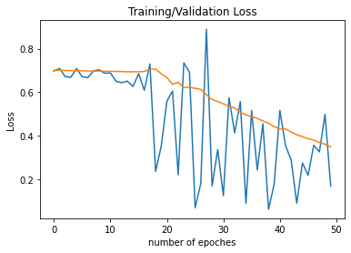

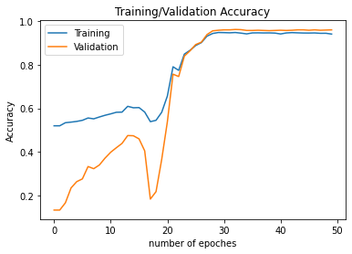

```
Final Training Accuracy: 0.9394793566572708
Final Validation Accuracy: 0.9587443946188341
```

```python
# From the previous attempt (attempt #4), by adding a average layer in the model, we observed an increase in accuracy.

# The fifth attemp (attempt #5), is used to test the hidden units size within the model, that is unrelated to the optimizer.
# By setting all other perameters back to the original attemps, we increased hidden_size from 50 to 100.

model = RNN(len(text_field.vocab.itos), hidden_size=100, number_classes=2, pooling=0)
train(model, train, valid, batch_size=32, num_epoches=50, learning_rate=1e-5)
```

```
Epoch 1; Loss 0.694119; Train Acc 0.589289; Val Acc 0.354260
Epoch 2; Loss 0.698895; Train Acc 0.542862; Val Acc 0.204484
Epoch 3; Loss 0.704813; Train Acc 0.531587; Val Acc 0.157848
Epoch 4; Loss 0.690487; Train Acc 0.526115; Val Acc 0.150673
Epoch 5; Loss 0.705059; Train Acc 0.525949; Val Acc 0.149776
Epoch 6; Loss 0.709589; Train Acc 0.524789; Val Acc 0.147085
Epoch 7; Loss 0.692067; Train Acc 0.524789; Val Acc 0.147085
Epoch 8; Loss 0.716234; Train Acc 0.524457; Val Acc 0.147085
Epoch 9; Loss 0.712548; Train Acc 0.524291; Val Acc 0.147982
Epoch 10; Loss 0.703645; Train Acc 0.525120; Val Acc 0.147982
Epoch 11; Loss 0.719596; Train Acc 0.524789; Val Acc 0.147982
Epoch 12; Loss 0.710390; Train Acc 0.524789; Val Acc 0.147085
Epoch 13; Loss 0.743459; Train Acc 0.526778; Val Acc 0.150673
Epoch 14; Loss 0.543886; Train Acc 0.803847; Val Acc 0.692377
Epoch 15; Loss 0.652493; Train Acc 0.939148; Val Acc 0.924664
Epoch 16; Loss 0.618893; Train Acc 0.949262; Val Acc 0.944395
Epoch 17; Loss 0.548964; Train Acc 0.942961; Val Acc 0.959641
Epoch 18; Loss 0.558093; Train Acc 0.944951; Val Acc 0.960538
Epoch 19; Loss 0.530959; Train Acc 0.931852; Val Acc 0.959641
Epoch 20; Loss 0.446623; Train Acc 0.933013; Val Acc 0.958744
Epoch 21; Loss 0.604647; Train Acc 0.938484; Val Acc 0.962332
Epoch 22; Loss 0.445637; Train Acc 0.939148; Val Acc 0.960538
Epoch 23; Loss 0.450816; Train Acc 0.939645; Val Acc 0.960538
Epoch 24; Loss 0.520734; Train Acc 0.947272; Val Acc 0.960538
Epoch 25; Loss 0.355216; Train Acc 0.942464; Val Acc 0.962332
Epoch 26; Loss 0.404471; Train Acc 0.944122; Val Acc 0.964126
Epoch 27; Loss 0.276008; Train Acc 0.944619; Val Acc 0.963229
Epoch 28; Loss 0.423626; Train Acc 0.932681; Val Acc 0.962332
Epoch 29; Loss 0.340492; Train Acc 0.939977; Val Acc 0.961435
Epoch 30; Loss 0.355918; Train Acc 0.934008; Val Acc 0.962332
Epoch 31; Loss 0.414206; Train Acc 0.946112; Val Acc 0.964126
Epoch 32; Loss 0.307452; Train Acc 0.924722; Val Acc 0.959641
Epoch 33; Loss 0.317451; Train Acc 0.946775; Val Acc 0.963229
Epoch 34; Loss 0.307831; Train Acc 0.947438; Val Acc 0.963229
Epoch 35; Loss 0.566252; Train Acc 0.947107; Val Acc 0.962332
Epoch 36; Loss 0.340538; Train Acc 0.949428; Val Acc 0.963229
Epoch 37; Loss 0.265179; Train Acc 0.948765; Val Acc 0.963229
Epoch 38; Loss 0.573026; Train Acc 0.947770; Val Acc 0.964126
Epoch 39; Loss 0.250685; Train Acc 0.952081; Val Acc 0.962332
Epoch 40; Loss 0.206142; Train Acc 0.951418; Val Acc 0.963229
Epoch 41; Loss 0.554851; Train Acc 0.950589; Val Acc 0.963229
Epoch 42; Loss 0.221488; Train Acc 0.935832; Val Acc 0.968610
Epoch 43; Loss 0.208793; Train Acc 0.948931; Val Acc 0.966816
Epoch 44; Loss 0.232880; Train Acc 0.947272; Val Acc 0.965919
Epoch 45; Loss 0.213010; Train Acc 0.953905; Val Acc 0.964126
Epoch 46; Loss 0.581142; Train Acc 0.950257; Val Acc 0.968610
Epoch 47; Loss 0.143041; Train Acc 0.945117; Val Acc 0.970404
Epoch 48; Loss 0.153890; Train Acc 0.952413; Val Acc 0.963229
Epoch 49; Loss 0.244373; Train Acc 0.953242; Val Acc 0.968610
Epoch 50; Loss 0.137570; Train Acc 0.953573; Val Acc 0.965919
```

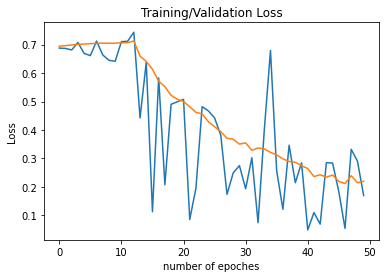

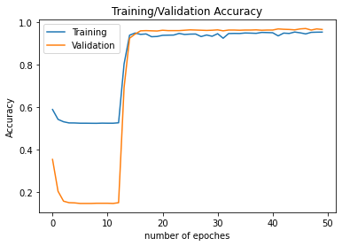

```
Final Training Accuracy: 0.9535732051069474
Final Validation Accuracy: 0.9659192825112107
```

```python
# From the previous attempt (attempt #5), by increasing the hidden units, the computational time increased, and we see an slightly increase on accuracy.

# The fifth attemp (attempt #6), we combined all previous observation, with the num_epoches = 50, a slightly higher learning_rate = 2e-5, pooling layer = 2 and hidden_size = 80.
model = RNN(len(text_field.vocab.itos), hidden_size=80, number_classes=2, pooling=2)
train(model, train, valid, batch_size=32, num_epoches=50, learning_rate=2e-5)
```

[output not shown]

Answer:

The hyperparameters that are tunned are num_epoches (5, 30, 50), learning_rate (1e-5, 1e-4, 2e-5), pooling layers (0, 1, 2) and hidden units (50, 100, 80). The number of pooling layers and hidden units are tunned on model that is not realted to the optimizer.

### Part (d) [2 pt]

Before we deploy a machine learning model, we usually want to have a better understanding of how our model performs beyond its validation accuracy. An important metric to track is *how well our model performs in certain subsets of the data*.

In particular, what is the model's error rate amongst data with negative labels? This is called the **false positive rate**.

What about the model's error rate amongst data with positive labels? This is called the **false negative rate**.

Report your final model's false positive and false negative rate across the validation set.

```python
# Create a Dataset of only spam validation examples
valid_spam = torchtext.legacy.data.Dataset(
                                [e for e in valid.examples if e.label == 1],
                                valid.fields)
# Create a Dataset of only non-spam validation examples
valid_nospam = torchtext.legacy.data.Dataset(
                                [e for e in valid.examples if e.label == 0],
                                valid.fields)

val_spam_iter = torchtext.legacy.data.BucketIterator(valid_spam,
                          batch_size=32,
                          sort_key=lambda x: len(x.sms),
                          sort_within_batch=True,
                          repeat=False)

val_nospam_iter = torchtext.legacy.data.BucketIterator(valid_nospam,
                          batch_size=32,
                          sort_key=lambda x: len(x.sms),
                          sort_within_batch=True,
                          repeat=False)
```

```python
print("what is the model's error rate amongst data with negative labels? This is called the false positive rate")
print(1-get_accuracy(model, val_nospam_iter))
print("What about the model's error rate amongst data with positive labels? This is called the false negative rate")
print(1-get_accuracy(model, val_spam_iter))
```

```
what is the model's error rate amongst data with negative labels? This is called the false positive rate
0.023834196891191706
What about the model's error rate amongst data with positive labels? This is called the false negative rate
0.07999999999999996
```

### Part (e) [2 pt]

The impact of a false positive vs a false negative can be drastically different. If our spam detection algorithm was deployed on your phone, what is the impact of a false positive on the phone's user? What is the impact of a false negative?

Answer:

False positive is when a non-spam(0) that is predicted as a spam(1). False negative is when a spam(1) that is predicted as a non-spam(0).

The false positive case is predicted an important message as not important one, it may have a more significant impact on the phone's user. Since, the user may miss very significant messages because the algorithm missed categorized the type.

The false negative is prediced an spam message as important one, it will cause too much impact on user, since they did not missed the message, it is just a waste of time for the user to read the spam message.

## Part 4. Evaluation [11 pt]

### Part (a) [1 pt]

Report the final test accuracy of your model.

```python
test_iter = torchtext.legacy.data.BucketIterator(test,
                          batch_size=32,
                          sort_key=lambda x: len(x.sms),
                          sort_within_batch=True,
                          repeat=False)

print("Final test accuracy on the best model:", get_accuracy(model, test_iter))
```

```
Final test accuracy on the best model: 0.9542190305206463
```

### Part (b) [3 pt]

Report the false positive rate and false negative rate of your model across the test set.

```python
# Create a Dataset of only spam validation examples
test_spam = torchtext.legacy.data.Dataset(
                                [e for e in test.examples if e.label == 1],
                                test.fields)
# Create a Dataset of only non-spam validation examples
test_nospam = torchtext.legacy.data.Dataset(
                                [e for e in test.examples if e.label == 0],
                                test.fields)

test_spam_iter = torchtext.legacy.data.BucketIterator(test_spam,
                          batch_size=32,
                          sort_key=lambda x: len(x.sms),
                          sort_within_batch=True,
                          repeat=False)

test_nospam_iter = torchtext.legacy.data.BucketIterator(test_nospam,
                          batch_size=32,
                          sort_key=lambda x: len(x.sms),
                          sort_within_batch=True,
                          repeat=False)
```

```python
print("False positive rate: ")
print(1-get_accuracy(model, test_nospam_iter))
print("False negative rage")
print(1-get_accuracy(model, test_spam_iter))
```

```
False positive rate:
0.04455958549222794
False negative rage
0.046979865771812124
```

### Part (c) [3 pt]

What is your model's prediction of the **probability** that the SMS message "machine learning is sooo cool!" is spam?

Hint: To begin, use `text_field.vocab.stoi` to look up the index of each character in the vocabulary.

```python
msg = "machine learning is sooo cool!"

msg_lst = []
for i in msg:
    msg_lst.append(text_field.vocab.stoi[i])

probability = F.softmax(model(torch.tensor(msg_lst).unsqueeze(0)).detach(), dim=1) # use the softmax function to compute probability

print("Probability of the message is not spam: " + str(float(probability[0][0])))
print("Probability of the message is spam: " + str(float(probability[0][1])))
```

```
Probability of the message is not spam: 0.8266943097114563
Probability of the message is spam: 0.17330561578273773
```

### Part (d) [4 pt]

Do you think detecting spam is an easy or difficult task?

Since machine learning models are expensive to train and deploy, it is very important to compare our models against baseline models: a simple model that is easy to build and inexpensive to run that we can compare our recurrent neural network model against.

Explain how you might build a simple baseline model. This baseline model can be a simple neural network (with very few weights), a hand-written algorithm, or any other strategy that is easy to build and test.

**Do not actually build a baseline model. Instead, provide instructions on how to build it.**

Answer:

I think detecting spam is a difficult task.

The possible baseline model can be built is based on the number of occurance on words that are highly possible to be appeared in the spam messages.

So, first of all we can learned from the words witin the spam messages, and count on the number of occurance of each words. Then filter out the words that are occur the highest to be as a spam vocabulary list. Then we can predict a message if it is spam or not by seeing the high freqnecy occured words are inside the spam vocabulary list or not, and determine if the message is spam or not.